# Evolving Trends in Cyber Events: Insights from a Decade of Data

- Show All Code
- Hide All Code
- View Source

Author

Annie Goodman & Etiene Effiong

Published

December 8, 2024

# Primary Research Question

How have the tactics, targets, and motives of cyber actors evolved over the last decade?

# Introduction

The number of cyber events has surged in recent years, with a reported 38% increase in 2022 [(Checkpoint Blog, 2023)](https://blog.checkpoint.com/2023/01/05/38-increase-in-2022-global-cyberattacks/). As digital infrastructure becomes essential to daily life, military operations, healthcare, and education, cybercriminals have adapted, employing increasingly sophisticated tactics. Cyber events encompass a wide range of activities, including social media manipulation and fake news generation, prompting an important question: beyond frequency, what else has changed in this landscape?

Despite advancements in cybersecurity, accurately attributing these events to their perpetrators remains a significant challenge. Attackers frequently utilize evasion techniques, such as VPNs and proxy servers, to obscure their identity, location, and motives. False flag operations complicate this issue, as misattributions can have severe consequences. Nation-states have increasingly participated in this arena, posing serious threats to global stability. The disruption caused by an accidental software glitch earlier this year illustrates the risks involved—if such incidents can lead to widespread damage, the potential impact of a malicious actor could be catastrophic.

This research explores the evolution of cyber events over the past decade, focusing on key questions such as whether we have improved in attributing these events, how nation-states are leveraging cyber attacks to gain advantages, and which nations are the most frequent perpetrators. We will also investigate whether industries have been targeted differently based on perpetrator type and event frequency, along with examining relationships between actor countries and their targets. Lastly, we will conduct text analysis of event descriptions to identify patterns in motives and the descriptive language used. These insights aim to inform future defense strategies, helping businesses and governments better manage the growing threat of cyber events.

# Data

The dataset used for this analysis is sourced from the [(University of Maryland School of Public Policy, CISSM-Center for International & Security Studies)](https://cissm.umd.edu/research-impact/publications/cyber-events-database-home)

*Reference*

Harry, C., & Gallagher, N. (2018). Classifying Cyber Events. *Journal of Information Warfare*, 17(3), 17-31.

*Description*

This dataset includes cyber events recorded from January 2014 to August 2024, detailing various aspects of each incident, such as the type of threat actor, their motives, targeted industries, and the outcomes of the events. It comprises 15 columns and 13,841 rows, pre-processed by the CISSM research team to ensure accuracy and completeness.

The data is collected through a Python script designed to scrape information from reputable sources on both the open and dark web. This script automatically extracts key details, including publication date, title, and URL, which are subsequently reviewed and coded by the CISSM team. Each event is classified using a standard taxonomy, with attributions drawn from the original source material rather than the team’s interpretation.

While the dataset provides valuable insights into cyber event patterns and trends, it does come with limitations. The scraping process is restricted to specific URLs, which may result in the omission of some events. Furthermore, since the sources are human-generated, they can be subject to biases, inaccuracies, or misleading information. Despite these concerns, we believe that the dataset and its underlying framework will yield high-quality insights into the evolving landscape of cyber events.

```r
# Cleaning data

df <- df |>
    mutate(event_subtype = str_replace_all(event_subtype, "\\bServer\\b", "Servers"),
           event_subtype = str_replace_all(event_subtype, "\\bService\\b", "Services"),
           event_subtype = str_replace_all(event_subtype, "\\bSensor\\b", "Sensors"),
           event_subtype = str_replace_all(event_subtype, "\\bHost\\b", "Hosts"),
           event_subtype = str_replace_all(event_subtype, "\\bUndetermined\\b", "Unknown"),
           event_subtype = str_replace_all(event_subtype, "\\bUser\\b", "Users"),
           actor_type = str_replace_all(actor_type, "\\bHacktvist\\b", "Hacktivist"),
           industry_code = case_when(
               industry_code == 92 & industry == "Professional, Scientific, and Technical Services" ~ 54,
               industry_code == 99 & industry == "Public Administration" ~ 92,
               industry == "Medusa" ~ industry_code,  # Preserve the industry code here
               TRUE ~ industry_code),
           industry = case_when(
               industry == "Medusa" ~ "Undetermined",
               TRUE ~ industry)) |>
    drop_na(event_subtype) |>
    separate_rows(event_subtype, sep = ",|;") |>
    mutate(event_subtype = str_trim(event_subtype),
           year = as.integer(year))
```

## Data Snippet

```r
head(df)
```

```
# A tibble: 6 × 15
  event_date  year month actor    actor_type organization industry_code industry
  <chr>      <int> <chr> <chr>    <chr>      <chr>                <dbl> <chr>
1 2014-01-01  2014 01    Undeter… Criminal   Barry Unive…            61 Educati…
2 2014-01-01  2014 01    Undeter… Criminal   Record Assi…            54 Profess…
3 2014-01-01  2014 01    Syrian … Hacktivist Skype's Soc…            54 Profess…
4 2014-01-02  2014 01    Undeter… Criminal   Snapchat                51 Informa…
5 2014-01-03  2014 01    DERP Tr… Undetermi… Battle.net              51 Informa…
6 2014-01-03  2014 01    DERP Tr… Undetermi… Club Penguin            51 Informa…
# ℹ 7 more variables: motive <chr>, event_type <chr>, event_subtype <chr>,
#   description <chr>, source_url <chr>, country <chr>, actor_country <chr>
```

## Summary Statistics

```r
# Events per Year
events_per_year <- df |>
  filter(year < 2024) |>
  rename(Year = year) |>
  group_by(Year) |>
  summarise(Events = n()) |>
  arrange(Year)

events_per_year_table <- events_per_year |>
  knitr::kable("html", caption = "Number of Cyber Events per Year") |>
  kableExtra::kable_styling(bootstrap_options = c("striped", "hover")) |>
  kableExtra::row_spec(0, background = "#931e18", color = "white") |>
  kableExtra::column_spec(1, bold = TRUE, color = "#2A3C4E") |>
  kableExtra::column_spec(2, bold = TRUE, color = "#2A3C4E")

# Most Frequent Target Countries (Top 5)
most_frequent_target_countries <- df |>
  group_by(country) |>
  summarise(Count = n()) |>
  arrange(desc(Count)) |>
  head(5) |>
  rename(Country = country)

# Render Most Frequent Target Countries Table
target_countries_table <- most_frequent_target_countries |>
  knitr::kable("html", caption = "Most Frequent Target Countries") |>
  kableExtra::kable_styling(bootstrap_options = c("striped", "hover")) |>
  kableExtra::row_spec(0, background = "#4A6073", color = "white") |>
  kableExtra::column_spec(1, bold = TRUE, color = "#2A3C4E")

# Most Frequent Actor Countries (Top 5)
most_frequent_actor_countries <- df |>
  filter(!actor_country == "Undetermined") |>
  group_by(actor_country) |>
  summarise(Count = n()) |>
  arrange(desc(Count)) |>
  head(5) |>
  rename(Actor_Country = actor_country)

# Render Most Frequent Actor Countries Table
actor_countries_table <- most_frequent_actor_countries |>
  knitr::kable("html", caption = "Most Frequent Actor Countries") |>
  kableExtra::kable_styling(bootstrap_options = c("striped", "hover")) |>
  kableExtra::row_spec(0, background = "#da7901", color = "white") |>
  kableExtra::column_spec(1, bold = TRUE, color = "#2A3C4E")

# List of unique Actor Types and Event Types
actor_types_list <- unique(df$actor_type)
event_types_list <- unique(df$event_type)

# Create a table for Actor Types and Event Types
types_table <- data.frame(
  Statistic = c("Unique Actor Types", "Unique Event Types"),
  Value = c(paste(actor_types_list, collapse = ", "),
            paste(event_types_list, collapse = ", ")),
  stringsAsFactors = FALSE
) |>
  knitr::kable("html", caption = "Actor and Event Types") |>
  kableExtra::kable_styling(bootstrap_options = c("striped", "hover")) |>
  kableExtra::row_spec(0, background = "#247d3f", color = "white") |>
  kableExtra::column_spec(1, bold = TRUE, color = "#2A3C4E")

# Print all tables
events_per_year_table
```

Number of Cyber Events per Year

| Year | Events |
| --- | --- |
| 2014 | 667 |
| 2015 | 941 |
| 2016 | 1209 |
| 2017 | 874 |
| 2018 | 946 |
| 2019 | 1225 |
| 2020 | 2221 |
| 2021 | 1784 |
| 2022 | 2618 |
| 2023 | 2446 |

```r
actor_countries_table
```

Most Frequent Actor Countries

| Actor_Country | Count |
| --- | --- |
| Russian Federation | 2043 |
| China | 213 |
| Korea (the Democratic People's Republic of) | 172 |
| United States of America | 160 |
| Ukraine | 136 |

```r
target_countries_table
```

Most Frequent Target Countries

| Country | Count |
| --- | --- |
| United States of America | 7410 |
| United Kingdom of Great Britain and Northern Ireland | 844 |
| Italy | 455 |
| Canada | 417 |
| Ukraine | 417 |

```r
types_table
```

Actor and Event Types

| Statistic | Value |
| --- | --- |
| Unique Actor Types | Criminal, Hacktivist, Undetermined, Hobbyist, Nation-State, Terrorist |
| Unique Event Types | Exploitive, Disruptive, Mixed, Undetermined |

# Data exploration and visualization

With our data now cleaned and ready, we dived straight into the analysis to uncover the trends our research aims to highlight. This thorough exploration enabled us to identify patterns in cyber incidents, including variations in actor types and their motivations. By scrutinizing these trends, we can gain insights into how technological advancements shape the dynamics of cyber events.

## Event Subtypes Over Time

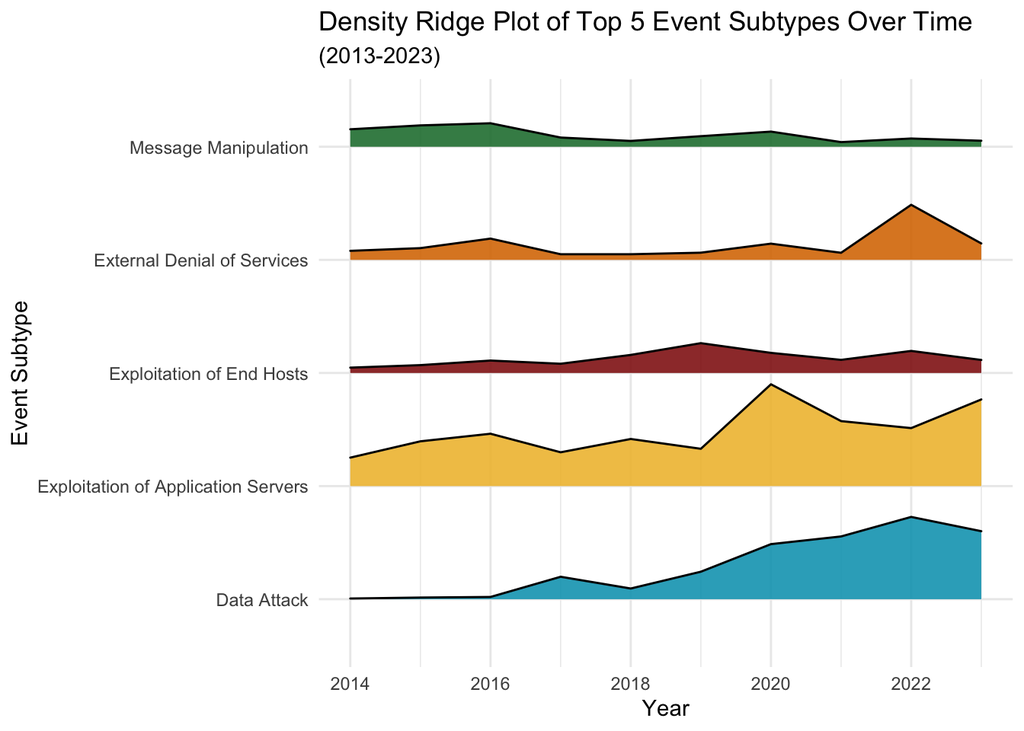

```r
density_plot_df <- df |>
    filter(year <= 2023)  # Filter data to include only up to 2023

density_plot_df |>
    group_by(year, event_subtype) |>
    summarize(count = n(), .groups = "drop") |>
    group_by(event_subtype) |>
    summarize(total_count = sum(count), .groups = "drop") |>
    top_n(5, total_count) |>
    inner_join(density_plot_df, by = "event_subtype") |>  # Use the filtered dataset here
    group_by(year, event_subtype) |>
    summarize(count = n(), .groups = "drop") |>
    ggplot(aes(x = year, y = event_subtype, height = count, fill = event_subtype)) +
    geom_density_ridges(scale = 0.9, alpha = 0.9, stat = "identity") +
    scale_fill_manual(values = custom_palette) +
    labs(title = "Density Ridge Plot of Top 5 Event Subtypes Over Time",
         subtitle = "(2013-2023)",
         x = "Year",
         y = "Event Subtype") +
    theme_minimal() +
    theme(legend.position = "none")
```

## Proportion of Cyber Attacks by Nation-State Actors Across Industries

```r
# Define critical infrastructure codes
critical_infrastructure_codes <- c(51, 48, 11, 22, 62, 52, 92, 31, 33, 21)

# Function to analyze actor proportions
analyze_actor_proportions <- function(df) {
  # Add critical infrastructure flag
  df <- df %>%
    mutate(is_critical = industry_code %in% critical_infrastructure_codes)

  # Calculate proportions for all industries
  actor_proportions <- df %>%
    group_by(industry_code, industry) %>%
    summarise(
      total_events = n(),
      nation_state_events = sum(actor_type == "Nation-State"),
      proportion_nation_state = nation_state_events / total_events,
      .groups = 'drop'
    ) %>%
    arrange(desc(proportion_nation_state))

  # Calculate proportions specifically for critical infrastructure
  critical_proportions <- df %>%
    group_by(is_critical) %>%
    summarise(
      total_events = n(),
      nation_state_events = sum(actor_type == "Nation-State"),
      proportion_nation_state = nation_state_events / total_events,
      .groups = 'drop'
    )

  return(list(
    actor_proportions = actor_proportions,
    critical_proportions = critical_proportions
  ))
}

# Create visualizations
plot_actor_proportions <- function(actor_proportions) {
  # Industry-specific proportions plot
  p1 <- ggplot(actor_proportions,
               aes(x = reorder(as.factor(industry_code), -proportion_nation_state),
                   y = proportion_nation_state,
                   text = paste("Industry:", industry,
                                "<br>Proportion:", round(proportion_nation_state * 100, 1), "%",
                                "<br>Nation-State Events:", nation_state_events,
                                "<br>Total Events:", total_events))) +
    geom_bar(stat = "identity", fill = "#2A3C4E", width = .75) +
    labs(
      title = "Proportion of Nation-State Actors by Industry",
      x = "Industry Code",
      y = "Proportion"
    ) +
    theme(
      plot.title = element_text(size = 12),  # Reduced title size
      axis.title = element_text(size = 10),  # Reduced axis titles size
      axis.text.x = element_text(angle = 45, hjust = 1, size = 8),  # Reduced x-axis text
      axis.text.y = element_text(size = 8),  # Reduced y-axis text
      aspect.ratio = 1/2
    )

  # Convert ggplot to plotly for interactivity
  p1_interactive <- ggplotly(p1, tooltip = "text")

  return(p1_interactive)  # Return the Plotly version of the plot
}


# Example usage:
results <- analyze_actor_proportions(df)

# Display tables
kable(results$actor_proportions,
caption = "Proportion of Nation-State Events by Industry") %>%
kable_styling()
```

Proportion of Nation-State Events by Industry

| industry_code | industry | total_events | nation_state_events | proportion_nation_state |
| --- | --- | --- | --- | --- |
| 21 | Mining, Quarrying, and Oil and Gas Extraction | 77 | 15 | 0.1948052 |
| 99 | Undetermined | 236 | 44 | 0.1864407 |
| 49 | Transportation and Warehousing | 6 | 1 | 0.1666667 |
| 22 | Utilities | 304 | 45 | 0.1480263 |
| 92 | Public Administration | 2896 | 303 | 0.1046271 |
| 81 | Other Services (except Public Administration) | 1042 | 108 | 0.1036468 |
| 51 | Information | 1515 | 128 | 0.0844884 |
| 55 | Management of Companies and Enterprises | 25 | 2 | 0.0800000 |
| 48 | Transportation and Warehousing | 477 | 34 | 0.0712788 |
| 31 | Manufacturing | 615 | 32 | 0.0520325 |
| 52 | Finance and Insurance | 1425 | 72 | 0.0505263 |
| 54 | Professional, Scientific, and Technical Services | 1290 | 54 | 0.0418605 |
| 11 | Agriculture, Forestry, Fishing and Hunting | 24 | 1 | 0.0416667 |
| 71 | Arts, Entertainment, and Recreation | 448 | 14 | 0.0312500 |
| 44 | Retail Trade | 499 | 14 | 0.0280561 |
| 56 | Administrative and Support and Waste Management and Remediation Services | 191 | 5 | 0.0261780 |
| 61 | Educational Services | 1485 | 30 | 0.0202020 |
| 33 | Manufacturing | 73 | 1 | 0.0136986 |
| 53 | Real Estate and Rental and Leasing | 97 | 1 | 0.0103093 |
| 62 | Health Care and Social Assistance | 2081 | 18 | 0.0086497 |
| 42 | Wholesale Trade | 121 | 1 | 0.0082645 |
| 72 | Accommodation and Food Services | 323 | 2 | 0.0061920 |
| 23 | Construction | 51 | 0 | 0.0000000 |
| 32 | Manufacturing | 14 | 0 | 0.0000000 |
| 45 | Retail Trade | 11 | 0 | 0.0000000 |

```r
kable(results$critical_proportions,
caption = "Nation-State Events in Critical vs Non-Critical Infrastructure") %>%
kable_styling()
```

Nation-State Events in Critical vs Non-Critical Infrastructure

| is_critical | total_events | nation_state_events | proportion_nation_state |
| --- | --- | --- | --- |
| FALSE | 5839 | 276 | 0.0472684 |
| TRUE | 9487 | 649 | 0.0684094 |

```r
# Create interactive plot
plot_actor_proportions(results$actor_proportions)
```

[interactive chart not shown]

Our analysis reveals a compelling pattern in the landscape of cyber attacks, particularly when it comes to nation-state operations. Critical infrastructure, the backbone of modern society, emerges as a preferred target for nation-state actors. When nation-states strike in cyberspace, their targeting preference is stark: 70.2% of their attacks are aimed at critical infrastructure, while only 29.8% target non-critical sectors.

In absolute numbers, this translates to 649 attacks on critical infrastructure versus 276 on non-critical targets, out of 925 total nation-state incidents. This isn’t random chance - it reflects a deliberate targeting strategy where nation-states concentrate their efforts on sectors that could provide maximum strategic impact through potential infrastructure disruption.

## Annual Event Count Across Actor Types

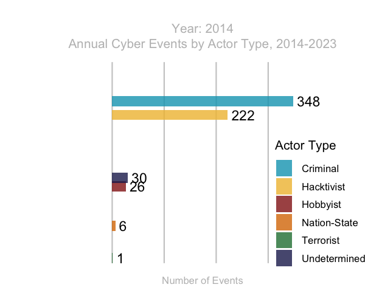

Cyber threat trends from 2014 to 2023 demonstrate a fundamental transformation in attack patterns. The chart reveals that criminal actors have become the primary threat vector, with incidents increasing from 348 to 2,081 over the nine-year period. This shift coincides with a decline in amateur attacks and a rise in sophisticated operations. Nation-state-actors’ activities increased from 6 to 106 incidents, while hacktivist operations showed significant variability, peaking at 658 events in 2022. The overall increase in cyber events from 633 (2014) to 2,443 (2023) reflects the intensification of cyber threats and suggests a trend toward more organized, well-resourced threat actors.

```r
actor_event_count <- actor_clean_df %>%
    filter(year < 2024) |>
    group_by(year, actor_type) %>%
    summarise(event_count = n(), .groups = 'drop') %>%
    mutate(
        rank = rank(-event_count),  # Compute rank for sorting
        Value_lbl = paste0(' ', round(event_count))  # Create Value_lbl for labels
    )

actor_race_anim <- actor_event_count %>%
    mutate(year = as.integer(year)) %>%  # Convert year to integer
    ggplot(aes(x = rank, y = event_count, fill = actor_type)) +  # Use fill for color
    geom_bar(stat = "identity", position = "dodge", width = 3, alpha = 0.8) +
    geom_text(aes(y = event_count, label = Value_lbl), hjust = 0) +
    coord_flip(clip = 'off', expand = FALSE) +
    scale_y_continuous(labels = scales::comma) +
    scale_fill_manual(values = custom_palette) +
    scale_x_reverse() +
    theme_minimal() +
    theme(
        axis.line = element_blank(),
        axis.text = element_blank(),
        axis.ticks = element_blank(),
        axis.title = element_blank(),
        plot.title = element_text(
            size = 10, hjust = 0.5, face = 'bold',
            colour = 'grey', vjust = -1),  # Reduced title font size
        plot.subtitle = element_text(
            size = 10, hjust = 0.5,
            face = 'italic', color = 'grey'),
        plot.caption = element_text(
            size = 8, hjust = 0.5,
            face = 'italic', color = 'grey'),
        plot.margin = margin(0.5, 2, 0.5, 3, 'cm'),
        # Only vertical gridlines (major x-axis gridlines)
        panel.grid.major.x = element_line(color = "grey80"),
        panel.grid.major.y = element_blank(),
        # Adjust the legend size and position
        legend.position = c(0.9, 0.3),
        legend.background = element_rect(fill = 'white'),
        legend.title = element_text(size = 10),  # Reduce legend title size
        legend.text = element_text(size = 8),  # Reduce legend label size
        legend.key.size = unit(0.5, "cm")  # Reduce size of the legend keys (color boxes)
    ) +
    transition_time(year) +  # Use year as discrete variable
    view_follow(fixed_x = TRUE) +
    labs(title = 'Year: {frame_time}',
         subtitle = 'Annual Cyber Events by Actor Type, 2014-2023',
         fill = 'Actor Type',
         caption = 'Number of Events')

# Animate with reduced size
animate(actor_race_anim, duration = 17, end_pause = 15,
        width = 600, height = 500, res = 150,
        fps = 20,  # Set FPS to a factor of 100 (20 is a factor of 100)
        renderer = gifski_renderer("actor_race_anim.gif"))
```

## Distribution of Motives by Actor Type

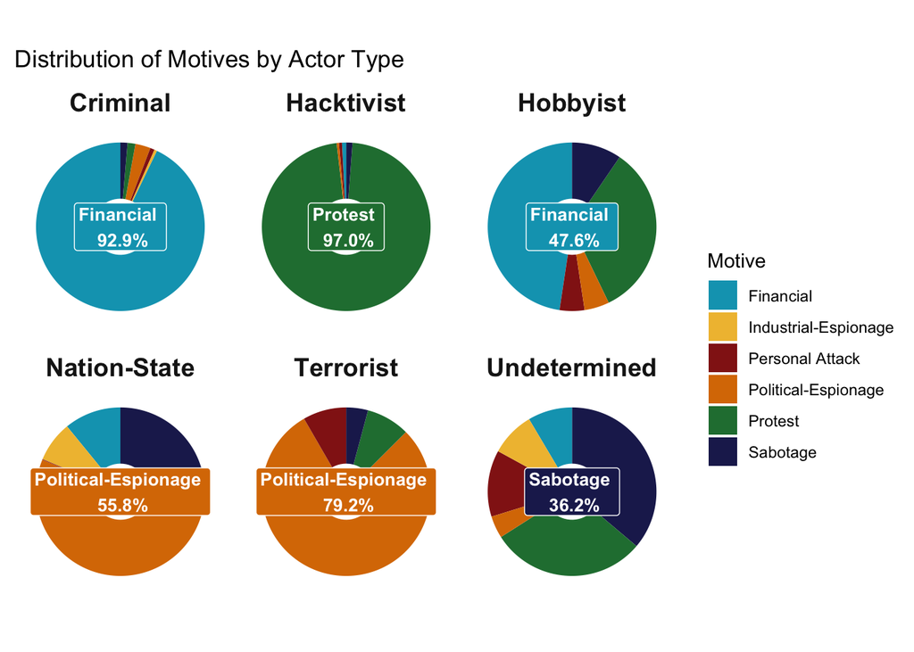

```r
# Preprocess motive data
motive_data <- df |>
    filter(!motive == "Undetermined") |>
    separate_rows(motive, sep = ",|;") |>
    mutate(motive = str_trim(motive)) |>
    group_by(actor_type, motive) |>
    summarize(count = n(), .groups = 'drop') |>
    arrange(desc(count))

# Calculate proportions for pie chart
motive_data <- motive_data |>
    group_by(actor_type) |>
    mutate(proportion = count / sum(count)) |>
    ungroup()

# Identify the largest slice for each actor type
largest_labels <- motive_data |>
    group_by(actor_type) |>
    filter(proportion == max(proportion)) |>
    mutate(
        label = paste(motive, "\n", scales::percent(proportion, accuracy = 0.1))  # Create label text
    ) |>
    ungroup()

# Create pie chart with labels matching slice colors
ggplot(motive_data, aes(x = 1, y = proportion, fill = motive)) +
    geom_bar(stat = "identity", width = 1) +
    coord_polar(theta = "y") +
    facet_wrap(~ actor_type, scales = "free") +
    scale_fill_manual(values = custom_palette) +
    # Add labels at the center of each pie chart with a dynamic color box
    geom_label(
        data = largest_labels,
        aes(
            x = 0,
            y = 0,
            label = label,
            fill = motive
        ),
        inherit.aes = FALSE,
        size = 3.5,
        color = "white",
        label.padding = unit(0.2, "lines"),  # Padding for the label box
        fontface = "bold",
        show.legend = FALSE  # Don't include these in the legend
    ) +
    labs(
        title = "Distribution of Motives by Actor Type",
        x = NULL,
        y = NULL,
        fill = "Motive"
    ) +
    theme_minimal() +
    theme(
        axis.ticks = element_blank(),
        axis.text = element_blank(),  # This removes both x and y axis text
        axis.title = element_blank(),  # This removes both x and y axis titles
        panel.grid = element_blank(),
        strip.text = element_text(size = 14, face = "bold")  # Larger and bolder facet titles
    )
```

These charts show the proportions of attributable motives by actor type which are mostly as expected, given our existing knowledge of the topic. `Criminals` are motivated by `financial` gains. `Hacktivists` are generally protesting something. `Nation-states` and `terrorists` are committing acts of `political espionage`.

The two most interesting results, however, are the `Hobbyists` and the `Unknown` actors. `Hobbyists` had a substantial proportion of `financial` motivation, but also a significant amount of `protests`, which led us to wonder how the dataset is coded between hobbyist and `Hacktivist`. We were unable to determine how these are coded based on the information provided in the source data, but it would be a potential future avenue for research. The differences between a criminal actor, a hacktivist, and a hobbyist seem as though they may be hard to pinpoint.

This is something we will explore more as the project goes on. We were hoping to find some attributable qualities in the undetermined group, such as a strong linkage to a specific type, but it seems pretty distributed. Fittingly, however, that graph has the largest proportion of sabotage motivations, which makes sense given that those people are usually trying not to be identified.

## Monthly Trend Analysis

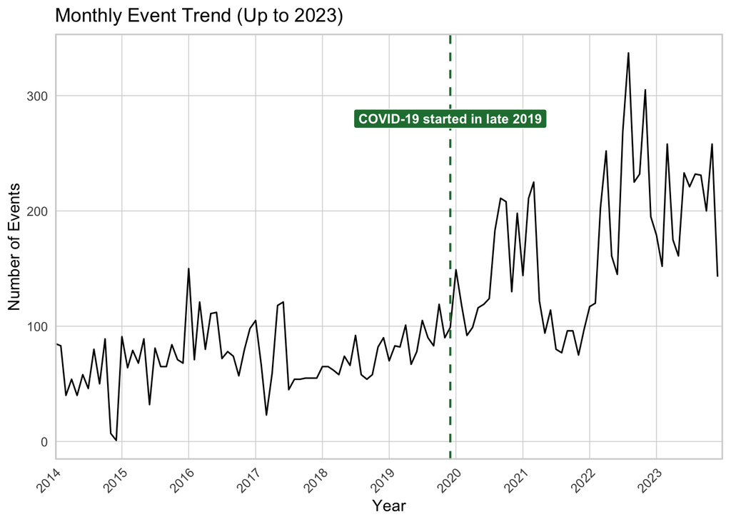

```r
# Convert event_date to Date format
actor_clean_df$event_date <- as.Date(actor_clean_df$event_date)

# Filter the data to include events up to 2023
actor_clean_df_filtered <- actor_clean_df %>%
  filter(year <= 2023)

# Create a monthly summary
monthly_summary <- actor_clean_df_filtered %>%
  group_by(year, month) %>%
  summarise(event_count = n())

ggplot(monthly_summary, aes(x = as.Date(paste(year, month, "01", sep = "-")), y = event_count)) +
  geom_line() +
  labs(
    x = "Year",
    y = "Number of Events",
    title = "Monthly Event Trend (Up to 2023)"
  ) +
  theme_minimal() +
  scale_x_date(
    date_breaks = "1 year",
    date_labels = "%Y",
    limits = as.Date(c("2014-01-01", "2023-12-31")),
    expand = c(0, 0)
  ) +
  # Add reference line at the start of COVID-19 (December 2019)
  geom_vline(xintercept = as.Date("2019-12-01"), col = "#247d3f", linetype = 'dashed', size = .7) +
  # Add annotation with background
  annotate(
    'label',
    x = as.Date("2019-12-01"),
    y = 280,
    label = 'COVID-19 started in late 2019',
    color = "white",
    fill = "#247d3f",  # Background color matching the line
    size = 3.2,
    fontface = "bold",
    label.padding = unit(0.3, "lines")  # Add padding for better readability
  ) +
  theme(
    axis.text.x = element_text(angle = 45, hjust = 1),
    panel.grid.major = element_line(color = "lightgray", size = .25),
    panel.grid.minor = element_blank(),
    panel.border = element_rect(color = "lightgray", fill = NA, size = 1)
  )
```

However, starting in 2020, there is a marked rise in the frequency of cyber events, coinciding with the onset of the COVID-19 pandemic, which likely contributed to a surge in digital activity and, consequently, cyber incidents. This period is characterized by significant spikes, with the highest number of events occurring around 2022. The peaks during these years suggest increased vulnerability or heightened detection and reporting of cyber incidents.

In late 2023, there is a noticeable decline in the number of events, although this could be due to delayed reporting for more recent months. Overall, the chart indicates a shift from relatively stable trends pre-2020 to a more volatile and elevated rate of cyber events in the last few years, highlighting the growing prominence and complexity of cyber security challenges.

# Conclusion

Our analysis reveals significant changes in the frequency, nature, and impact of cyber events over the past decade. The increasing dominance of sophisticated actors, such as nation-states and organized criminal groups, underscores the shift from amateur attacks to highly strategic operations. Critical infrastructure remains a primary target, reflecting the strategic importance of these sectors for nation-state actors. The rise in data breaches and exploitation of application servers highlights the growing reliance on digital systems and the vulnerabilities they introduce.

Temporal trends, such as the surge during the COVID-19 pandemic, show how global crises can amplify cyber threats, while a late-2023 decline may signal delays in reporting or shifts in attacker strategies. Analysis of motives confirms known patterns—criminals are financially driven, hacktivists pursue ideological goals, and nation-states engage in espionage—while posing questions about underexplored categories like hobbyists and undetermined actors. These findings emphasize the need for adaptive, motive-specific defenses and robust real-time monitoring systems.

Our report provides a foundation for further research into the interplay of actors, motives, and industry-specific impacts. Future analysis will delve deeper into the relationships between attacker nations and their targets, refine motive categorizations, and explore the language patterns in event descriptions. These efforts aim to better equip policymakers and organizations to combat the evolving landscape of cyber threats.

# Attribution

All members contributed equally.

# Appendix

**Data dictionary**

[output not shown]

[output cut: 5 more lines]